# Hidden vs Visible Resources in the Survival Game (Experiment 3)

Scott Claessens

2020-05-27

# 0. Setup

You’ll need to download [Stan](http://mc-stan.org/) to your machine for these analyses.

Load in the data from Experiment 3.

| ID | Group | IDinGroup | Condition | Payment | TimeStarted | Age | Sex | Language | rounds_survived | total_cattle_lost | overall_total_amount_requested | overall_total_amount_received | overall_total_amount_given | overall_received_given_totaldiff | overall_mean_amount_requested | overall_mean_amount_received | overall_mean_amount_given | overall_num_shocks | overall_num_requests_made | overall_num_requests_when_under_threshold | overall_num_requests_responded_to | overall_repetitive_giving | overall_repetitive_asking | payment_for_lobby | payment_from_game | attention | feel_bad_ask | fairness | risk_pooling_true | … |
| --- | --- | --- | --- | --- | --- | --- | --- | --- | --- | --- | --- | --- | --- | --- | --- | --- | --- | --- | --- | --- | --- | --- | --- | --- | --- | --- | --- | --- | --- | --- |
| 1 | 1 | 1 | 1 | 3.95 | 2019-08-27 20:35:26.994342+00:00 | 29 | 3 | 1 | 7 | 32 | 22 | 1 | 7 | -6 | 3.1428571 | 0.14285714 | 1.0000000 | 3 | 4 | 4 | 2 | 0 | 0 | 0 | 46 | 6 | 3 | 4 | 4 | … |
| 2 | 1 | 2 | 1 | 5.39 | 2019-08-27 20:33:08.550976+00:00 | 28 | 1 | 1 | 25 | 43 | 44 | 7 | 1 | 6 | 1.7600000 | 0.28000000 | 0.0400000 | 3 | 6 | 5 | 1 | 0 | 3 | 2 | 188 | 6 | 4 | 3 | 2 | … |
| 3 | 2 | 1 | 1 | 5.59 | 2019-08-27 20:41:43.054960+00:00 | 21 | 1 | 1 | 25 | 49 | 16 | 21 | 13 | 8 | 0.6400000 | 0.84000000 | 0.5200000 | 4 | 6 | 0 | 3 | 1 | 4 | 1 | 208 | 3 | 3 | 4 | 5 | … |
| 4 | 2 | 2 | 1 | 5.96 | 2019-08-27 20:38:10.881016+00:00 | 21 | 2 | 1 | 25 | 23 | 9 | 13 | 21 | -8 | 0.3600000 | 0.52000000 | 0.8400000 | 2 | 3 | 0 | 5 | 3 | 1 | 26 | 221 | 6 | 4 | 5 | 5 | … |
| 5 | 3 | 1 | 1 | 5.35 | 2019-08-27 20:49:58.650505+00:00 | 18 | 1 | 1 | 25 | 41 | 52 | 14 | 19 | -5 | 2.0800000 | 0.56000000 | 0.7600000 | 3 | 18 | 1 | 10 | 5 | 9 | 0 | 186 | 1 | 2 | 3 | 3 | … |
| 6 | 3 | 2 | 1 | 5.81 | 2019-08-27 20:47:56.858992+00:00 | 39 | 2 | 1 | 25 | 21 | 27 | 19 | 14 | 5 | 1.0800000 | 0.76000000 | 0.5600000 | 3 | 12 | 0 | 8 | 3 | 5 | 15 | 218 | 6 | 3 | 3 | 4 | … |
| 7 | 4 | 1 | 1 | 5.38 | 2019-08-27 20:49:34.266959+00:00 | 33 | 1 | 1 | 25 | 65 | 5 | 3 | 3 | 0 | 0.2000000 | 0.12000000 | 0.1200000 | 5 | 1 | 0 | 1 | 0 | 0 | 10 | 178 | 6 | 4 | 5 | 5 | … |
| 8 | 4 | 2 | 1 | 5.82 | 2019-08-27 20:53:06.391080+00:00 | 29 | 2 | 1 | 25 | 65 | 3 | 3 | 3 | 0 | 0.1200000 | 0.12000000 | 0.1200000 | 5 | 1 | 0 | 1 | 0 | 0 | 0 | 233 | 6 | 4 | 5 | 5 | … |
| 9 | 5 | 1 | 1 | 5.20 | 2019-08-27 20:48:33.230516+00:00 | 46 | 1 | 2 | 25 | 66 | 22 | 18 | 2 | 16 | 0.8800000 | 0.72000000 | 0.0800000 | 6 | 3 | 3 | 1 | 0 | 2 | 0 | 170 | 6 | 2 | 5 | 5 | … |
| 10 | 5 | 2 | 1 | 3.85 | 2019-08-27 20:51:44.746951+00:00 | 42 | 2 | 1 | 5 | 14 | 2 | 2 | 18 | -16 | 0.4000000 | 0.40000000 | 3.6000000 | 2 | 1 | 1 | 3 | 2 | 0 | 4 | 31 | 6 | 4 | 4 | 4 | … |

[output cut: 74 more lines]

Each row is a different participant in the study (there were 84). Columns 1-36 are variables that summarise the whole session, while the rest of the columns specify the events that occurred in each of the 25 rounds.

# 1. Binomial - Number of shocks

We’ll trim the dataset, to make it more manageable.

| Condition | rounds_survived | overall_num_shocks |
| --- | --- | --- |
| 1 | 7 | 3 |
| 1 | 25 | 3 |
| 1 | 25 | 4 |
| 1 | 25 | 2 |
| 1 | 25 | 3 |
| 1 | 25 | 3 |
| 1 | 25 | 5 |
| 1 | 25 | 5 |
| 1 | 25 | 6 |
| 1 | 5 | 2 |

[output cut: 74 more lines]

In this dataset, Condition == 1 implies that the participant played the Survival Game in the ‘Hidden’ condition. Unlike in Study 1, ‘Hidden’ here means that Player 2’s resources were hidden, while Player 1’s resources were visible as normal. Condition == 0 refers to the standard ‘Visible’ control condition.

We first test whether the probability of a shock occurring differs between the two conditions. All analyses in this document will use the `brm()` function. Learn more about the **brms** package [here](https://github.com/paul-buerkner/brms).

```
## function(d3.01) {
##   brm(data = d3.01, family = binomial,
##       overall_num_shocks | trials(rounds_survived) ~ 0 + Intercept + Condition,
##       prior = c(prior(normal(0, 1), class = b)),
##       sample_prior = TRUE,
##       iter = 2000, warmup = 1000, chains = 4, cores = 4,
##       seed = 2113)
## }
```

Priors.

| prior | class | coef | group | resp | dpar | nlpar | bound |
| --- | --- | --- | --- | --- | --- | --- | --- |
| normal(0, 1) | b |  |  |  |  |  |  |
|  | b | Condition |  |  |  |  |  |
|  | b | Intercept |  |  |  |  |  |

Let’s look at the results.

```
##  Family: binomial
##   Links: mu = logit
## Formula: overall_num_shocks | trials(rounds_survived) ~ 0 + Intercept + Condition
##    Data: d3.01 (Number of observations: 84)
## Samples: 4 chains, each with iter = 2000; warmup = 1000; thin = 1;
##          total post-warmup samples = 4000
##
## Population-Level Effects:
##           Estimate Est.Error l-95% CI u-95% CI Rhat Bulk_ESS Tail_ESS
## Intercept    -1.43      0.09    -1.61    -1.26 1.00     1391     1787
## Condition    -0.00      0.12    -0.24     0.24 1.00     1384     1883
##
## Samples were drawn using sampling(NUTS). For each parameter, Bulk_ESS
## and Tail_ESS are effective sample size measures, and Rhat is the potential
## scale reduction factor on split chains (at convergence, Rhat = 1).
```

The probability of a shock occuring does not differ across conditions.

# 2. Gaussian - Total amount of cattle lost due to shocks

Trim the dataset again.

| Condition | total_cattle_lost |
| --- | --- |
| 1 | 32 |
| 1 | 43 |
| 1 | 49 |
| 1 | 23 |
| 1 | 41 |
| 1 | 21 |
| 1 | 65 |
| 1 | 65 |
| 1 | 66 |
| 1 | 14 |

[output cut: 74 more lines]

We now fit a model to determine if the total amount of cattle lost due to shocks varies between conditions.

```
## function(d3.02) {
##   brm(data = d3.02, family = gaussian,
##       total_cattle_lost ~ 0 + Intercept + Condition,
##       prior = c(prior(normal(0, 100), class = b, coef = 'Intercept'),
##                 prior(normal(0, 5), class = b, coef = 'Condition')),
##       sample_prior = TRUE,
##       iter = 2000, warmup = 1000, chains = 4, cores = 4,
##       seed = 2113)
## }
```

The priors we used.

| prior | class | coef | group | resp | dpar | nlpar | bound |
| --- | --- | --- | --- | --- | --- | --- | --- |
|  | b |  |  |  |  |  |  |
| normal(0, 5) | b | Condition |  |  |  |  |  |
| normal(0, 100) | b | Intercept |  |  |  |  |  |
| student_t(3, 0, 23) | sigma |  |  |  |  |  |  |

The results.

```
##  Family: gaussian
##   Links: mu = identity; sigma = identity
## Formula: total_cattle_lost ~ 0 + Intercept + Condition
##    Data: d3.02 (Number of observations: 84)
## Samples: 4 chains, each with iter = 2000; warmup = 1000; thin = 1;
##          total post-warmup samples = 4000
##
## Population-Level Effects:
##           Estimate Est.Error l-95% CI u-95% CI Rhat Bulk_ESS Tail_ESS
## Intercept    44.38      2.86    38.74    49.86 1.00     2512     2795
## Condition    -3.11      3.35    -9.93     3.37 1.00     2377     2535
##
## Family Specific Parameters:
##       Estimate Est.Error l-95% CI u-95% CI Rhat Bulk_ESS Tail_ESS
## sigma    21.99      1.70    18.91    25.57 1.00     2885     2762
##
## Samples were drawn using sampling(NUTS). For each parameter, Bulk_ESS
## and Tail_ESS are effective sample size measures, and Rhat is the potential
## scale reduction factor on split chains (at convergence, Rhat = 1).
```

The total amount of cattle lost does not vary between conditions.

# 3. Binomial - Probability of requesting

Get a long-format data frame with binary request decisions over all rounds. If request == NA, player has died and been removed from the game, so we drop those rows. We also retain only Player 2s.

| ID | Group | IDinGroup | Condition | round_number | request |
| --- | --- | --- | --- | --- | --- |
| 2 | 1 | 2 | 1 | 1 | 1 |
| 4 | 2 | 2 | 1 | 1 | 0 |
| 6 | 3 | 2 | 1 | 1 | 1 |
| 8 | 4 | 2 | 1 | 1 | 0 |
| 10 | 5 | 2 | 1 | 1 | 1 |
| 12 | 6 | 2 | 1 | 1 | 0 |
| 14 | 7 | 2 | 1 | 1 | 1 |
| 16 | 8 | 2 | 1 | 1 | 1 |
| 18 | 9 | 2 | 1 | 1 | 0 |
| 20 | 10 | 2 | 1 | 1 | 0 |

[output cut: 667 more lines]

This leaves us with 677 request decisions.

We now fit a varying intercept and slope model, grouped by participant. We only allow the slope for round number to vary, as participants completed multiple rounds (within-subjects) but only one condition, Hidden or Visible (between-subjects).

```
## function(d3.03) {
##   brm(data = d3.03, family = bernoulli,
##       request ~ 0 + Intercept + round_number + Condition
##       + (0 + Intercept + round_number | ID),
##       prior = c(prior(normal(0, 1), class = b)),
##       sample_prior = TRUE,
##       iter = 2000, warmup = 1000, chains = 4, cores = 4,
##       control = list(adapt_delta = 0.95),
##       seed = 2113)
## }
```

Here are the priors for the model we just fitted.

| prior | class | coef | group | resp | dpar | nlpar | bound |
| --- | --- | --- | --- | --- | --- | --- | --- |
| normal(0, 1) | b |  |  |  |  |  |  |
|  | b | Condition |  |  |  |  |  |
|  | b | Intercept |  |  |  |  |  |
|  | b | round_number |  |  |  |  |  |
| lkj_corr_cholesky(1) | L |  |  |  |  |  |  |
|  | L |  | ID |  |  |  |  |
| student_t(3, 0, 10) | sd |  |  |  |  |  |  |
|  | sd |  | ID |  |  |  |  |
|  | sd | Intercept | ID |  |  |  |  |
|  | sd | round_number | ID |  |  |  |  |

Now let’s see the results.

```
##  Family: bernoulli
##   Links: mu = logit
## Formula: request ~ 0 + Intercept + round_number + Condition + (0 + Intercept + round_number | ID)
##    Data: d3.03 (Number of observations: 677)
## Samples: 4 chains, each with iter = 2000; warmup = 1000; thin = 1;
##          total post-warmup samples = 4000
##
## Group-Level Effects:
## ~ID (Number of levels: 42)
##                             Estimate Est.Error l-95% CI u-95% CI Rhat Bulk_ESS Tail_ESS
## sd(Intercept)                   1.50      0.36     0.86     2.31 1.00     1596     2108
## sd(round_number)                0.11      0.05     0.01     0.22 1.01      443      725
## cor(Intercept,round_number)    -0.00      0.40    -0.68     0.83 1.00     1404     1699
##
## Population-Level Effects:
##              Estimate Est.Error l-95% CI u-95% CI Rhat Bulk_ESS Tail_ESS
## Intercept       -0.66      0.38    -1.41     0.09 1.00     2091     2694
## round_number    -0.08      0.03    -0.16    -0.03 1.00     1812     1622
## Condition        0.13      0.49    -0.83     1.11 1.00     1947     2166
##
## Samples were drawn using sampling(NUTS). For each parameter, Bulk_ESS
## and Tail_ESS are effective sample size measures, and Rhat is the potential
## scale reduction factor on split chains (at convergence, Rhat = 1).
```

Plotting the parameters.

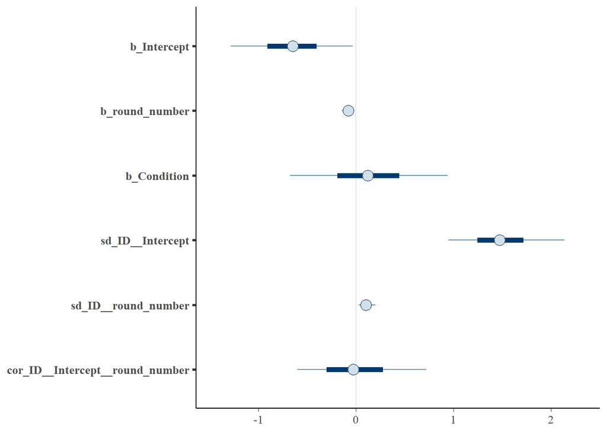

Trace plots to make sure Stan sampled efficiently.

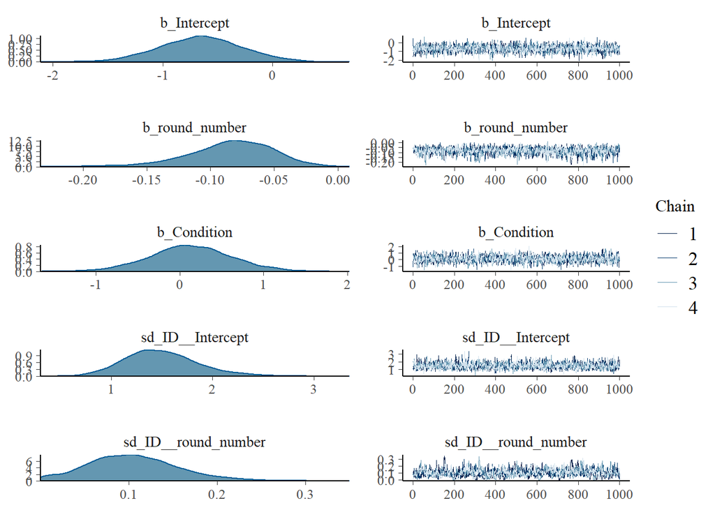

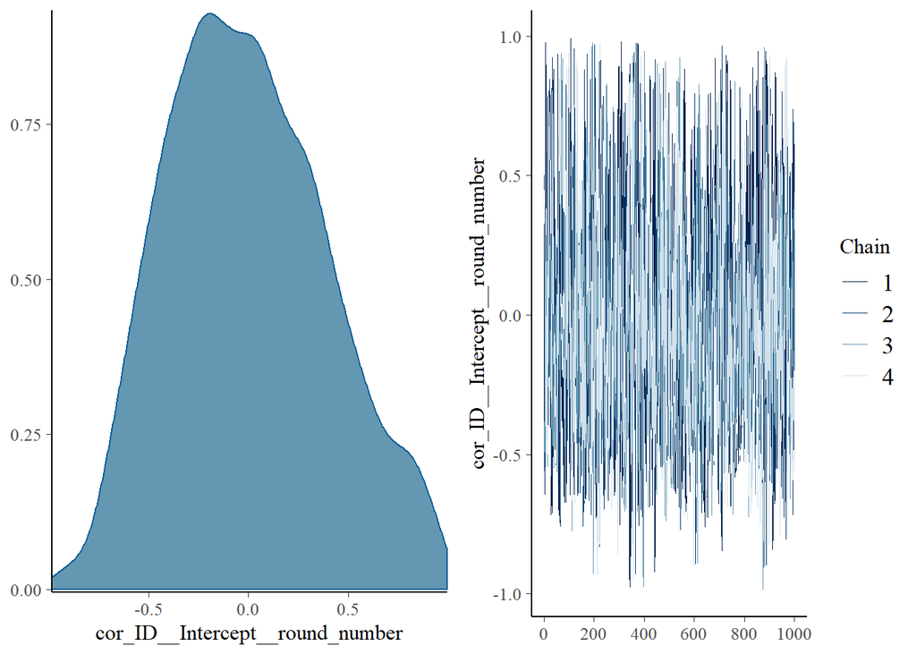

Looks like Stan sampled efficiently.

There seems to be no effect of condition on the probability of requesting for Player 2s.

Let’s sample from the posterior and convert to the probability scale.

```r
post <- readd(post3.03)

visible_prob <- inv_logit_scaled(post$b_Intercept)

visible_prob %>%
  median() %>%
  round(2)
```

```
## [1] 0.34
```

```r
hidden_prob  <- inv_logit_scaled(post$b_Intercept + post$b_Condition)

hidden_prob %>%
  median() %>%
  round(2)
```

```
## [1] 0.37
```

```r
difference <- hidden_prob - visible_prob
quantile(difference, c(0.025, 0.5, 0.975)) %>% round(2)
```

```
##  2.5%   50% 97.5%
## -0.19  0.03  0.25
```

Bayes factor for the difference between probabilities.

```
## [1] 0.58
```

This Bayes factor implies that we cannot be certain whether the difference between these probabilities is different or equal to zero, though it is verging on equal.

# 4. Binomial - Probability of requesting when above the minimum threshold

As before, get a long-format data frame with binary request decisions over all rounds. If request == NA, player has died and been removed from the game, so we drop those rows. However, we also filter out rows in which the player was below the minimum survival threshold (64 cattle). As before, we also retain only Player 2s.

| ID | IDinGroup | Condition | round_number | herd_size_after_shock | request |
| --- | --- | --- | --- | --- | --- |
| 4 | 2 | 1 | 1 | 72 | 0 |
| 6 | 2 | 1 | 1 | 71 | 1 |
| 8 | 2 | 1 | 1 | 72 | 0 |
| 14 | 2 | 1 | 1 | 73 | 1 |
| 16 | 2 | 1 | 1 | 68 | 1 |
| 18 | 2 | 1 | 1 | 74 | 0 |
| 22 | 2 | 1 | 1 | 64 | 1 |
| 24 | 2 | 1 | 1 | 68 | 1 |
| 28 | 2 | 1 | 1 | 73 | 0 |
| 30 | 2 | 1 | 1 | 72 | 0 |

[output cut: 590 more lines]

This leaves us with 600 request decisions.

Fit the varying intercept and slope model, grouped by participant.

```
## function(d3.04) {
##   brm(data = d3.04, family = bernoulli,
##       request ~ 0 + Intercept + round_number + Condition
##       + (0 + Intercept + round_number | ID),
##       prior = c(prior(normal(0, 1), class = b)),
##       sample_prior = TRUE,
##       iter = 2000, warmup = 1000, chains = 4, cores = 4,
##       control = list(adapt_delta = 0.95),
##       seed = 2113)
## }
```

Here are the priors for this model.

| prior | class | coef | group | resp | dpar | nlpar | bound |
| --- | --- | --- | --- | --- | --- | --- | --- |
| lkj_corr_cholesky(1) | L |  |  |  |  |  |  |
|  | L |  | ID |  |  |  |  |
| normal(0, 1) | b |  |  |  |  |  |  |
|  | b | Condition |  |  |  |  |  |
|  | b | Intercept |  |  |  |  |  |
|  | b | round_number |  |  |  |  |  |
| student_t(3, 0, 10) | sd |  |  |  |  |  |  |
|  | sd |  | ID |  |  |  |  |
|  | sd | Intercept | ID |  |  |  |  |
|  | sd | round_number | ID |  |  |  |  |

Let’s see the results.

```
##  Family: bernoulli
##   Links: mu = logit
## Formula: request ~ 0 + Intercept + round_number + Condition + (0 + Intercept + round_number | ID)
##    Data: d3.04 (Number of observations: 600)
## Samples: 4 chains, each with iter = 2000; warmup = 1000; thin = 1;
##          total post-warmup samples = 4000
##
## Group-Level Effects:
## ~ID (Number of levels: 39)
##                             Estimate Est.Error l-95% CI u-95% CI Rhat Bulk_ESS Tail_ESS
## sd(Intercept)                   1.61      0.44     0.86     2.58 1.00     1597     2274
## sd(round_number)                0.08      0.05     0.01     0.19 1.00      597     1116
## cor(Intercept,round_number)     0.00      0.46    -0.76     0.90 1.00     1561     1351
##
## Population-Level Effects:
##              Estimate Est.Error l-95% CI u-95% CI Rhat Bulk_ESS Tail_ESS
## Intercept       -0.94      0.42    -1.83    -0.15 1.00     1568     2442
## round_number    -0.10      0.04    -0.19    -0.04 1.00     1213     1397
## Condition       -0.28      0.52    -1.25     0.74 1.00     2071     2613
##
## Samples were drawn using sampling(NUTS). For each parameter, Bulk_ESS
## and Tail_ESS are effective sample size measures, and Rhat is the potential
## scale reduction factor on split chains (at convergence, Rhat = 1).
```

Plotting the parameters.

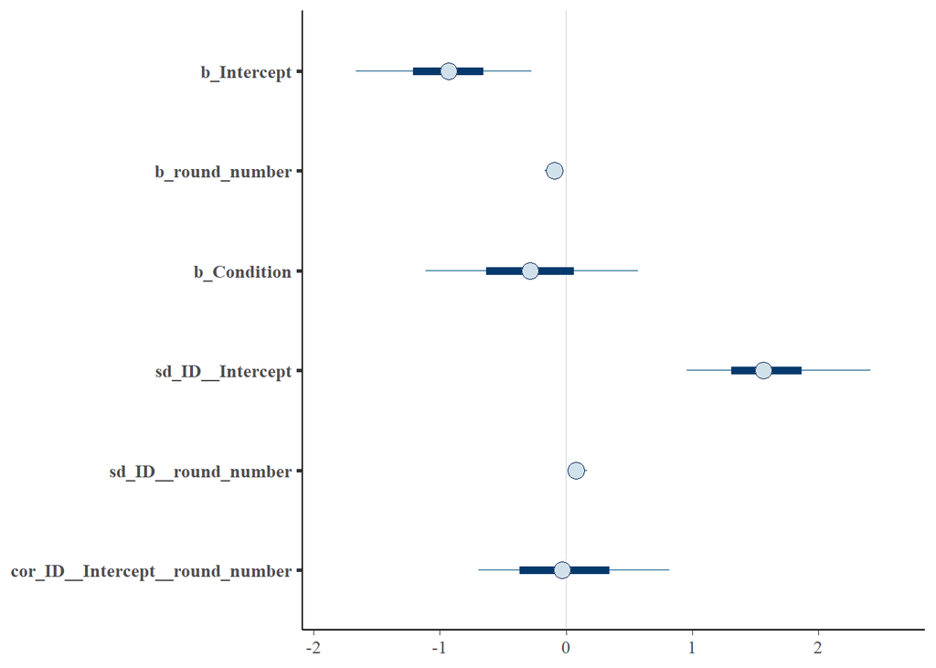

Trace plots to make sure Stan sampled efficiently.

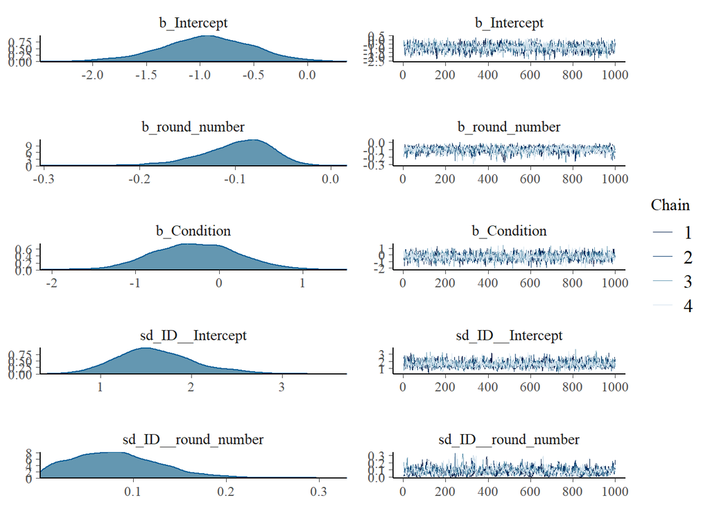

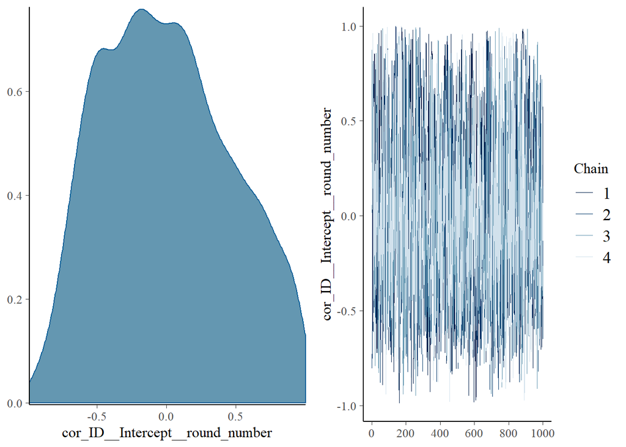

These HMC chains look healthy.

As with our previous model, it doesn’t look like condition is having an effect. Get the probabilities of requesting while above the threshold (greediness) in both conditions.

```r
post <- readd(post3.04)

visible_prob <- inv_logit_scaled(post$b_Intercept)

visible_prob %>%
  median() %>%
  round(2)
```

```
## [1] 0.28
```

```r
hidden_prob  <- inv_logit_scaled(post$b_Intercept + post$b_Condition)

hidden_prob %>%
  median() %>%
  round(2)
```

```
## [1] 0.23
```

```r
difference <- hidden_prob - visible_prob
quantile(difference, c(0.025, 0.5, 0.975)) %>% round(2)
```

```
##  2.5%   50% 97.5%
## -0.24 -0.05  0.14
```

Greediness is comparable across conditions. Get a Bayes factor for this difference.

```
## [1] 0.56
```

This Bayes factor implies that we cannot be certain whether the probabilities are different or equal.

# 5. Binomial - Probability of not responding to a request

Get long-format data frame with ‘received’ variable (i.e. how much a player received on any given round). We swap this around so it reflects how much the player *gave* to their partner (i.e. how much their partner received). We drop rows with NAs, since partners did not request help in that particular round. We then code whether the player gave nothing in response to the request (1) or gave at least one cattle (0). Finally, we retain only Player 2s.

| ID | IDinGroup | Condition | round_number | responded | notResponded |
| --- | --- | --- | --- | --- | --- |
| 6 | 2 | 1 | 1 | 0 | 1 |
| 8 | 2 | 1 | 1 | 3 | 0 |
| 12 | 2 | 1 | 1 | 1 | 0 |
| 20 | 2 | 1 | 1 | 0 | 1 |
| 22 | 2 | 1 | 1 | 1 | 0 |
| 30 | 2 | 1 | 1 | 4 | 0 |
| 32 | 2 | 1 | 1 | 0 | 1 |
| 42 | 2 | 1 | 1 | 5 | 0 |
| 46 | 2 | 0 | 1 | 3 | 0 |
| 48 | 2 | 0 | 1 | 1 | 0 |

[output cut: 184 more lines]

This leaves us with 194 possible responses to requests.

We then fit the varying intercept and slope model, again grouped by participant.

```
## function(d3.05) {
##   brm(data = d3.05, family = bernoulli,
##       notResponded ~ 0 + Intercept + round_number + Condition
##       + (0 + Intercept + round_number | ID),
##       prior = c(prior(normal(0, 1), class = b),
##                 prior(student_t(3, 0, 10), class = sd),
##                 prior(lkj(1), class = cor)),
##       sample_prior = TRUE,
##       iter = 2500, warmup = 1000, chains = 4, cores = 4,
##       control = list(adapt_delta = 0.99),
##       seed = 2113)
## }
```

Here are the priors for the model we just fitted.

| prior | class | coef | group | resp | dpar | nlpar | bound |
| --- | --- | --- | --- | --- | --- | --- | --- |
| lkj_corr_cholesky(1) | L |  |  |  |  |  |  |
|  | L |  | ID |  |  |  |  |
| normal(0, 1) | b |  |  |  |  |  |  |
|  | b | Condition |  |  |  |  |  |
|  | b | Intercept |  |  |  |  |  |
|  | b | round_number |  |  |  |  |  |
| student_t(3, 0, 10) | sd |  |  |  |  |  |  |
|  | sd |  | ID |  |  |  |  |
|  | sd | Intercept | ID |  |  |  |  |
|  | sd | round_number | ID |  |  |  |  |

The results.

```
##  Family: bernoulli
##   Links: mu = logit
## Formula: notResponded ~ 0 + Intercept + round_number + Condition + (0 + Intercept + round_number | ID)
##    Data: d3.05 (Number of observations: 194)
## Samples: 4 chains, each with iter = 2500; warmup = 1000; thin = 1;
##          total post-warmup samples = 6000
##
## Group-Level Effects:
## ~ID (Number of levels: 39)
##                             Estimate Est.Error l-95% CI u-95% CI Rhat Bulk_ESS Tail_ESS
## sd(Intercept)                   0.79      0.52     0.04     1.92 1.00     1379     2630
## sd(round_number)                0.10      0.07     0.00     0.28 1.01      747     1461
## cor(Intercept,round_number)     0.04      0.54    -0.91     0.95 1.00     1108     1612
##
## Population-Level Effects:
##              Estimate Est.Error l-95% CI u-95% CI Rhat Bulk_ESS Tail_ESS
## Intercept       -1.85      0.47    -2.83    -0.98 1.00     5085     4398
## round_number     0.04      0.04    -0.04     0.13 1.00     4574     3866
## Condition        1.01      0.51    -0.05     1.96 1.00     4357     3800
##
## Samples were drawn using sampling(NUTS). For each parameter, Bulk_ESS
## and Tail_ESS are effective sample size measures, and Rhat is the potential
## scale reduction factor on split chains (at convergence, Rhat = 1).
```

Plotting the parameters.

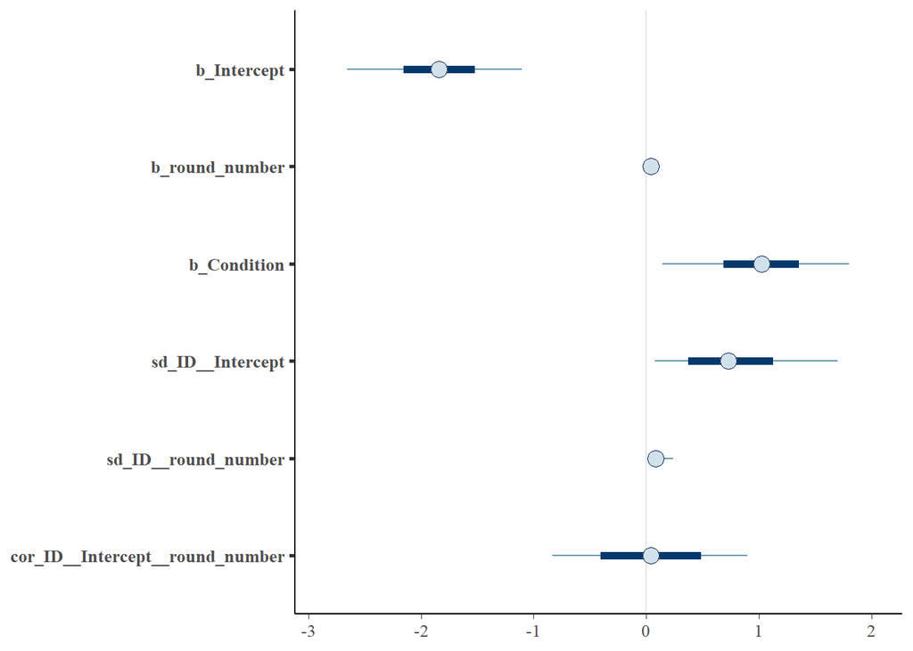

Let’s look at the trace plots to make sure Stan sampled efficiently.

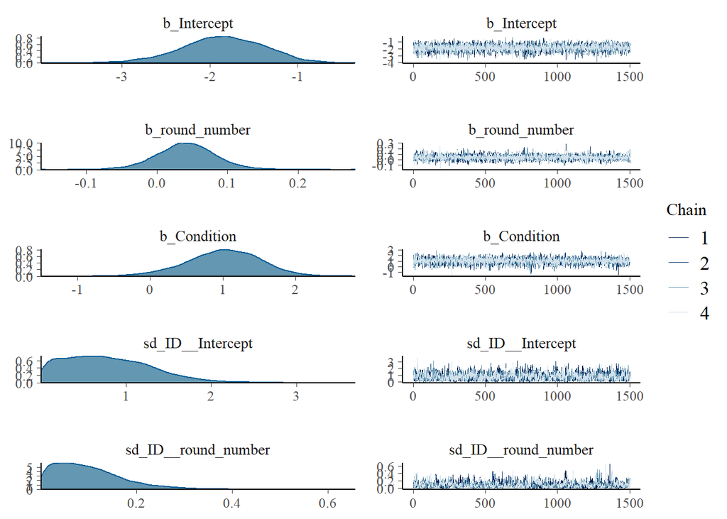

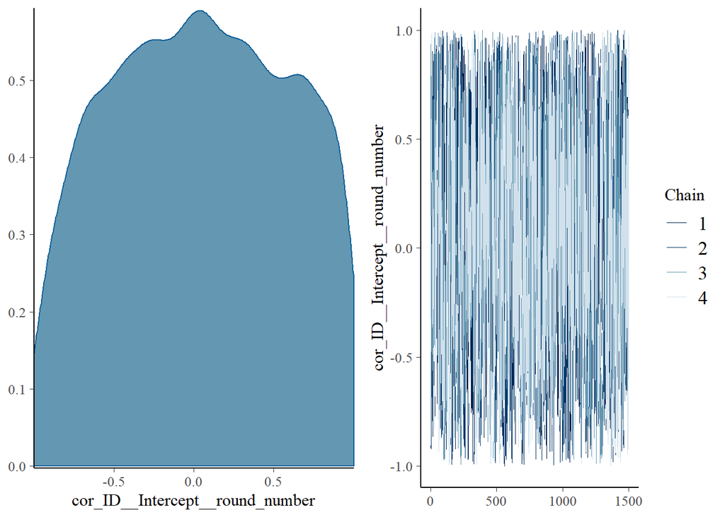

There’s an effect of condition. Let’s convert to probability scale.

```r
post <- readd(post3.05)

visible_prob <- inv_logit_scaled(post$b_Intercept)

visible_prob %>%
  median() %>%
  round(2)
```

```
## [1] 0.14
```

```r
hidden_prob  <- inv_logit_scaled(post$b_Intercept + post$b_Condition)

hidden_prob %>%
  median() %>%
  round(2)
```

```
## [1] 0.31
```

What’s the difference in probabilities between conditions?

```r
difference <- hidden_prob - visible_prob
quantile(difference, c(0.025, 0.5, 0.975)) %>% round(2)
```

```
##  2.5%   50% 97.5%
## -0.01  0.17  0.33
```

Bayes Factor.

```
## [1] 2.58
```

This Bayes Factor provides weak support for the hypothesis that the probabilities differ.

# 6. Binomial - Probability of not fulfilling a request when able

The data wrangling for this model is a little trickier.

1. First, we get a long-format data frame with (a) the player’s herd size that round, (b) how much the player received that round, and (c) how much the player requested that round.
2. Next, we flip the latter two variables to get (b’) how much the *player gave*, and (c’) how much the *player’s partner requested*. ‘Flipping’ is possible because partners sit next to the focal player in the data frame.
3. We drop rows with NAs, as no requesting happened this round.
4. We keep only rows in which the partner’s request could be fulfilled without dropping the player below the minimum survival threshold (i.e. the player was *able* to give).
5. We code whether the player fulfilled the request by giving what was asked or more (0) or did not fulfill the request (1).
6. We retain only Player 2s.

| ID | IDinGroup | Condition | round_number | herd_size_after_shock | gave | partner_requested | notFulfilled |
| --- | --- | --- | --- | --- | --- | --- | --- |
| 6 | 2 | 1 | 1 | 71 | 0 | 4 | 1 |
| 8 | 2 | 1 | 1 | 72 | 3 | 5 | 1 |
| 30 | 2 | 1 | 1 | 72 | 4 | 5 | 1 |
| 42 | 2 | 1 | 1 | 70 | 5 | 5 | 0 |
| 46 | 2 | 0 | 1 | 72 | 3 | 2 | 0 |
| 54 | 2 | 0 | 1 | 75 | 2 | 2 | 0 |
| 56 | 2 | 0 | 1 | 69 | 1 | 1 | 0 |
| 64 | 2 | 0 | 1 | 71 | 2 | 3 | 1 |
| 6 | 2 | 1 | 2 | 76 | 1 | 3 | 1 |
| 30 | 2 | 1 | 2 | 71 | 2 | 3 | 1 |

[output cut: 128 more lines]

This leaves us with 138 possible response decisions in which the player was able to give their partner what they asked for. Our outcome variable is whether they fulfilled that request or not.

We now fit the varying intercept and slope model, grouped by participant ID.

```
## function(d3.06) {
##   brm(data = d3.06, family = bernoulli,
##       notFulfilled ~ 0 + Intercept + round_number + Condition
##       + (0 + Intercept + round_number | ID),
##       prior = c(prior(normal(0, 1), class = b),
##                 prior(student_t(3, 0, 10), class = sd),
##                 prior(lkj(1), class = cor)),
##       control = list(adapt_delta = 0.99),
##       sample_prior = TRUE,
##       iter = 2500, warmup = 1000, chains = 4, cores = 4,
##       seed = 2113)
## }
```

Here are the priors.

| prior | class | coef | group | resp | dpar | nlpar | bound |
| --- | --- | --- | --- | --- | --- | --- | --- |
| lkj_corr_cholesky(1) | L |  |  |  |  |  |  |
|  | L |  | ID |  |  |  |  |
| normal(0, 1) | b |  |  |  |  |  |  |
|  | b | Condition |  |  |  |  |  |
|  | b | Intercept |  |  |  |  |  |
|  | b | round_number |  |  |  |  |  |
| student_t(3, 0, 10) | sd |  |  |  |  |  |  |
|  | sd |  | ID |  |  |  |  |
|  | sd | Intercept | ID |  |  |  |  |
|  | sd | round_number | ID |  |  |  |  |

Let’s see the results.

```
##  Family: bernoulli
##   Links: mu = logit
## Formula: notFulfilled ~ 0 + Intercept + round_number + Condition + (0 + Intercept + round_number | ID)
##    Data: d3.06 (Number of observations: 138)
## Samples: 4 chains, each with iter = 2500; warmup = 1000; thin = 1;
##          total post-warmup samples = 6000
##
## Group-Level Effects:
## ~ID (Number of levels: 31)
##                             Estimate Est.Error l-95% CI u-95% CI Rhat Bulk_ESS Tail_ESS
## sd(Intercept)                   1.69      0.79     0.39     3.54 1.00     1745     1726
## sd(round_number)                0.08      0.08     0.00     0.27 1.01      953     1246
## cor(Intercept,round_number)    -0.18      0.55    -0.96     0.90 1.00     3749     3462
##
## Population-Level Effects:
##              Estimate Est.Error l-95% CI u-95% CI Rhat Bulk_ESS Tail_ESS
## Intercept       -0.55      0.52    -1.58     0.47 1.00     3987     4136
## round_number    -0.02      0.04    -0.11     0.06 1.00     3676     2157
## Condition        0.84      0.64    -0.44     2.05 1.00     4025     4325
##
## Samples were drawn using sampling(NUTS). For each parameter, Bulk_ESS
## and Tail_ESS are effective sample size measures, and Rhat is the potential
## scale reduction factor on split chains (at convergence, Rhat = 1).
```

Plotting the parameters.

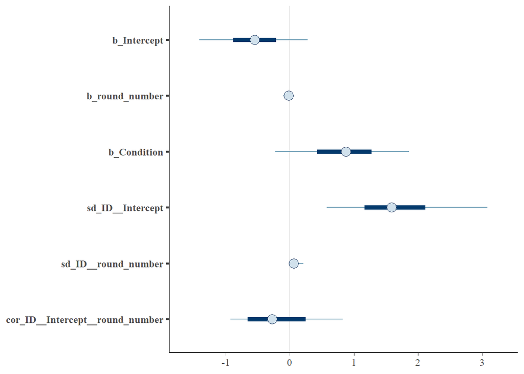

Let’s look at the trace plots to make sure Stan sampled efficiently.

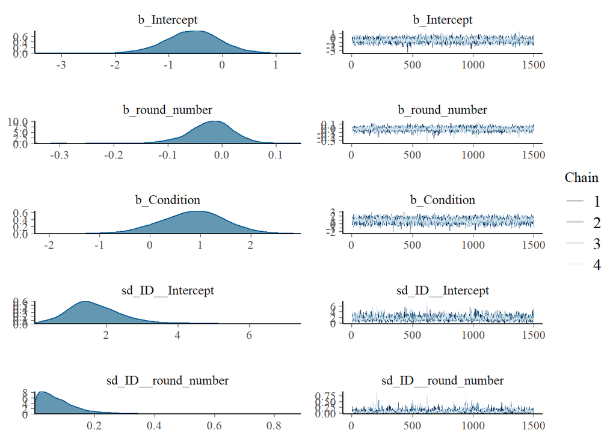

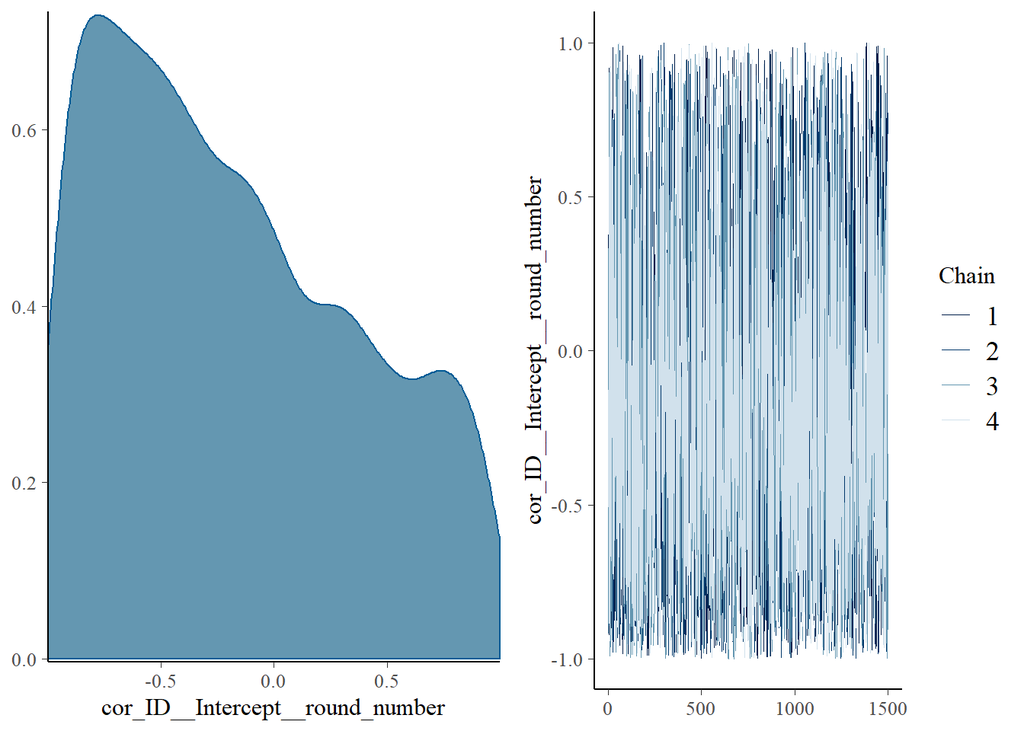

Again, the RHat values, n_eff values, and trace plots look okay.

Let’s get estimates on the absolute probability scale.

```r
post <- readd(post3.06)

visible_prob <- inv_logit_scaled(post$b_Intercept)

visible_prob %>%
  median() %>%
  round(2)
```

```
## [1] 0.37
```

```r
hidden_prob  <- inv_logit_scaled(post$b_Intercept + post$b_Condition)

hidden_prob %>%
  median() %>%
  round(2)
```

```
## [1] 0.58
```

```r
difference <- hidden_prob - visible_prob
quantile(difference, c(0.025, 0.5, 0.975)) %>% round(2)
```

```
##  2.5%   50% 97.5%
## -0.10  0.20  0.46
```

Bayes Factor.

```
## [1] 1.98
```

This Bayes Factor provides anecdotal support for the alternative (difference) over the null (no difference) hypothesis.

# 7. Survival analysis - Condition

Get the data, adding a column for `censored`.

| ID | IDinGroup | Group | Condition | rounds_survived | censored |
| --- | --- | --- | --- | --- | --- |
| 2 | 2 | 1 | 1 | 25 | 1 |
| 4 | 2 | 2 | 1 | 25 | 1 |
| 6 | 2 | 3 | 1 | 25 | 1 |
| 8 | 2 | 4 | 1 | 25 | 1 |
| 10 | 2 | 5 | 1 | 5 | 0 |
| 12 | 2 | 6 | 1 | 3 | 0 |
| 14 | 2 | 7 | 1 | 25 | 1 |
| 16 | 2 | 8 | 1 | 12 | 0 |
| 18 | 2 | 9 | 1 | 25 | 1 |
| 20 | 2 | 10 | 1 | 25 | 1 |

[output cut: 32 more lines]

Fit the survival model.

```
## function(d3.07) {
##   # one ID and Group per row so do not need the random effects
##   brm(rounds_survived | cens(censored) ~ 0 + Intercept + Condition,
##       data = d3.07, family = weibull, inits = "0",
##       prior = prior(normal(0, 2), class = b, coef = "Condition"),
##       iter = 2000, warmup = 1000, chains = 4, cores = 4,
##       sample_prior = TRUE, seed = 2113)
## }
```

What priors did we use?

| prior | class | coef | group | resp | dpar | nlpar | bound |
| --- | --- | --- | --- | --- | --- | --- | --- |
|  | b |  |  |  |  |  |  |
| normal(0, 2) | b | Condition |  |  |  |  |  |
|  | b | Intercept |  |  |  |  |  |
| gamma(0.01, 0.01) | shape |  |  |  |  |  |  |

Get the results.

```
##  Family: weibull
##   Links: mu = log; shape = identity
## Formula: rounds_survived | cens(censored) ~ 0 + Intercept + Condition
##    Data: d3.07 (Number of observations: 42)
## Samples: 4 chains, each with iter = 2000; warmup = 1000; thin = 1;
##          total post-warmup samples = 4000
##
## Population-Level Effects:
##           Estimate Est.Error l-95% CI u-95% CI Rhat Bulk_ESS Tail_ESS
## Intercept     4.39      0.69     3.39     6.07 1.00     1161     1336
## Condition    -0.39      0.60    -1.66     0.73 1.00     1548     1329
##
## Family Specific Parameters:
##       Estimate Est.Error l-95% CI u-95% CI Rhat Bulk_ESS Tail_ESS
## shape     0.88      0.21     0.51     1.33 1.00     1060     1548
##
## Samples were drawn using sampling(NUTS). For each parameter, Bulk_ESS
## and Tail_ESS are effective sample size measures, and Rhat is the potential
## scale reduction factor on split chains (at convergence, Rhat = 1).
```

Plot the parameters.

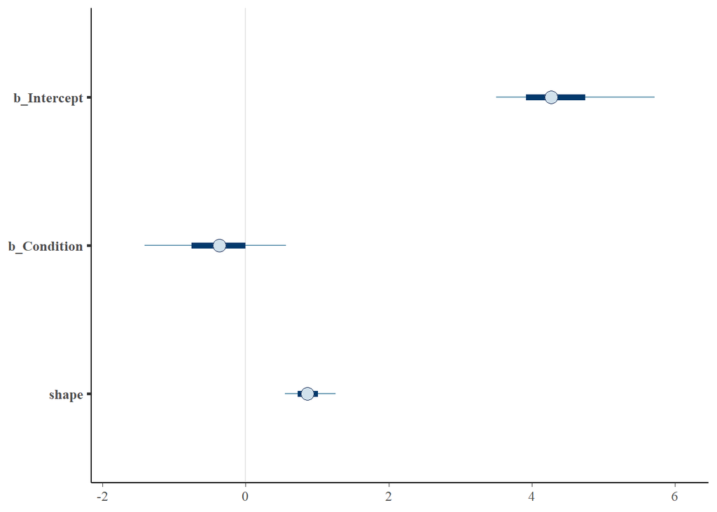

Estimate survival rate in the Visible condition.

```r
post <- readd(post3.07)

set.seed(2113)
srateVisible <- rweibull(4000, post$shape, exp(post$b_Intercept))
median(srateVisible)
```

```
## [1] 44.19926
```

Estimate survival rate in the Hidden condition.

```r
set.seed(2113)
srateHidden <- rweibull(4000, post$shape, exp(post$b_Intercept + post$b_Condition))
median(srateHidden)
```

```
## [1] 30.53829
```

Difference between these.

```r
difference <- srateHidden - srateVisible
quantile(difference, c(0.025, 0.5, 0.975)) %>% round(2)
```

```
##    2.5%     50%   97.5%
## -410.83   -6.96   75.01
```

# 8. Survival analysis - Proportion of Rule 1 cheating

Get data.

| ID | IDinGroup | Group | Condition | rounds_survived | censored | prop_rule1 |
| --- | --- | --- | --- | --- | --- | --- |
| 2 | 2 | 1 | 1 | 25 | 1 | 0.5000000 |
| 4 | 2 | 2 | 1 | 25 | 1 | 0.1200000 |
| 6 | 2 | 3 | 1 | 25 | 1 | 0.4800000 |
| 8 | 2 | 4 | 1 | 25 | 1 | 0.0400000 |
| 10 | 2 | 5 | 1 | 5 | 0 | 0.0000000 |
| 14 | 2 | 7 | 1 | 25 | 1 | 0.1111111 |
| 16 | 2 | 8 | 1 | 12 | 0 | 0.5000000 |
| 18 | 2 | 9 | 1 | 25 | 1 | 0.1200000 |
| 20 | 2 | 10 | 1 | 25 | 1 | 0.0000000 |
| 22 | 2 | 11 | 1 | 6 | 0 | 1.0000000 |

[output cut: 29 more lines]

Fit the model.

```
## function(d3.08) {
##   # one ID and Group per row so do not need the random effects
##   brm(rounds_survived | cens(censored) ~ 0 + Intercept + prop_rule1,
##       data = d3.08, family = weibull, inits = "0",
##       prior = prior(normal(0, 2), class = b, coef = "prop_rule1"),
##       iter = 2000, warmup = 1000, chains = 4, cores = 4,
##       sample_prior = TRUE, seed = 2113)
## }
```

Priors.

| prior | class | coef | group | resp | dpar | nlpar | bound |
| --- | --- | --- | --- | --- | --- | --- | --- |
|  | b |  |  |  |  |  |  |
|  | b | Intercept |  |  |  |  |  |
| normal(0, 2) | b | prop_rule1 |  |  |  |  |  |
| gamma(0.01, 0.01) | shape |  |  |  |  |  |  |

Print results.

```
##  Family: weibull
##   Links: mu = log; shape = identity
## Formula: rounds_survived | cens(censored) ~ 0 + Intercept + prop_rule1
##    Data: d3.08 (Number of observations: 39)
## Samples: 4 chains, each with iter = 2000; warmup = 1000; thin = 1;
##          total post-warmup samples = 4000
##
## Population-Level Effects:
##            Estimate Est.Error l-95% CI u-95% CI Rhat Bulk_ESS Tail_ESS
## Intercept      4.33      0.62     3.47     5.81 1.00     1180     1008
## prop_rule1    -0.79      0.90    -2.51     1.09 1.00     1712     1837
##
## Family Specific Parameters:
##       Estimate Est.Error l-95% CI u-95% CI Rhat Bulk_ESS Tail_ESS
## shape     1.03      0.28     0.56     1.63 1.00     1321     1310
##
## Samples were drawn using sampling(NUTS). For each parameter, Bulk_ESS
## and Tail_ESS are effective sample size measures, and Rhat is the potential
## scale reduction factor on split chains (at convergence, Rhat = 1).
```

Plot parameters.

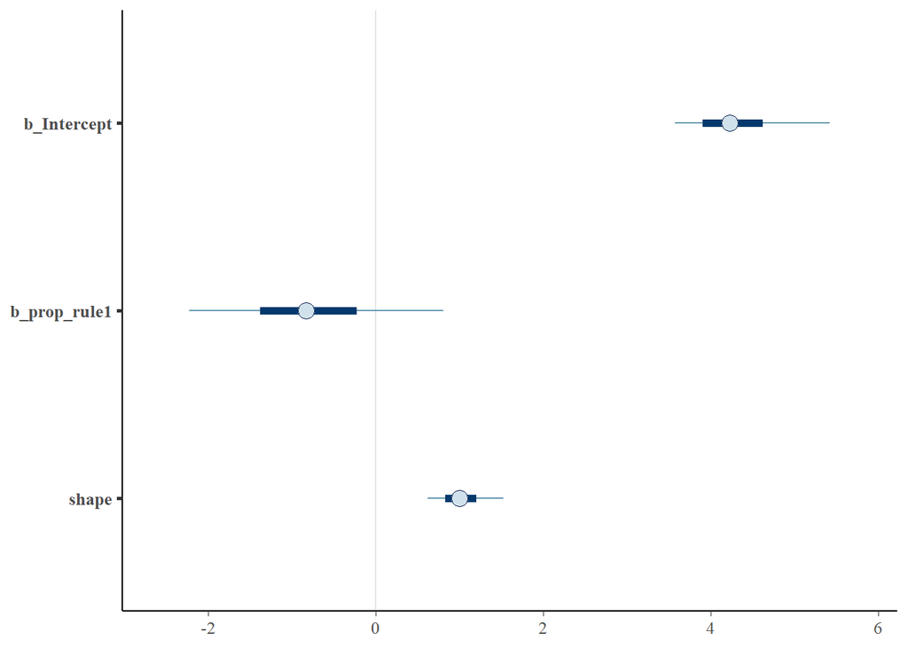

# 9. Survival analysis - Proportion of Rule 2 cheating

Get data.

| ID | IDinGroup | Group | Condition | rounds_survived | censored | prop_rule2 |
| --- | --- | --- | --- | --- | --- | --- |
| 4 | 2 | 2 | 1 | 25 | 1 | 0.5000000 |
| 6 | 2 | 3 | 1 | 25 | 1 | 0.7777778 |
| 8 | 2 | 4 | 1 | 25 | 1 | 1.0000000 |
| 14 | 2 | 7 | 1 | 25 | 1 | 0.7500000 |
| 16 | 2 | 8 | 1 | 12 | 0 | 0.0000000 |
| 20 | 2 | 10 | 1 | 25 | 1 | 0.6666667 |
| 24 | 2 | 12 | 1 | 9 | 0 | 0.0000000 |
| 30 | 2 | 15 | 1 | 11 | 0 | 0.6666667 |
| 32 | 2 | 16 | 1 | 25 | 1 | 1.0000000 |
| 34 | 2 | 17 | 1 | 25 | 1 | 0.6666667 |

[output cut: 21 more lines]

Fit the model.

```
## function(d3.09) {
##   # one ID and Group per row so do not need the random effects
##   brm(rounds_survived | cens(censored) ~ 0 + Intercept + prop_rule2,
##       data = d3.09, family = weibull, inits = "0",
##       prior = prior(normal(0, 2), class = b, coef = "prop_rule2"),
##       iter = 2000, warmup = 1000, chains = 4, cores = 4,
##       sample_prior = TRUE, seed = 2113, control = list(adapt_delta = 0.85))
## }
```

Priors.

| prior | class | coef | group | resp | dpar | nlpar | bound |
| --- | --- | --- | --- | --- | --- | --- | --- |
|  | b |  |  |  |  |  |  |
|  | b | Intercept |  |  |  |  |  |
| normal(0, 2) | b | prop_rule2 |  |  |  |  |  |
| gamma(0.01, 0.01) | shape |  |  |  |  |  |  |

Print results.

```
##  Family: weibull
##   Links: mu = log; shape = identity
## Formula: rounds_survived | cens(censored) ~ 0 + Intercept + prop_rule2
##    Data: d3.09 (Number of observations: 31)
## Samples: 4 chains, each with iter = 2000; warmup = 1000; thin = 1;
##          total post-warmup samples = 4000
##
## Population-Level Effects:
##            Estimate Est.Error l-95% CI u-95% CI Rhat Bulk_ESS Tail_ESS
## Intercept      3.93      0.78     3.02     6.00 1.00     1056      619
## prop_rule2     1.48      1.01    -0.30     3.73 1.01     1250     1163
##
## Family Specific Parameters:
##       Estimate Est.Error l-95% CI u-95% CI Rhat Bulk_ESS Tail_ESS
## shape     1.14      0.38     0.51     1.95 1.00      996      822
##
## Samples were drawn using sampling(NUTS). For each parameter, Bulk_ESS
## and Tail_ESS are effective sample size measures, and Rhat is the potential
## scale reduction factor on split chains (at convergence, Rhat = 1).
```

Plot parameters.

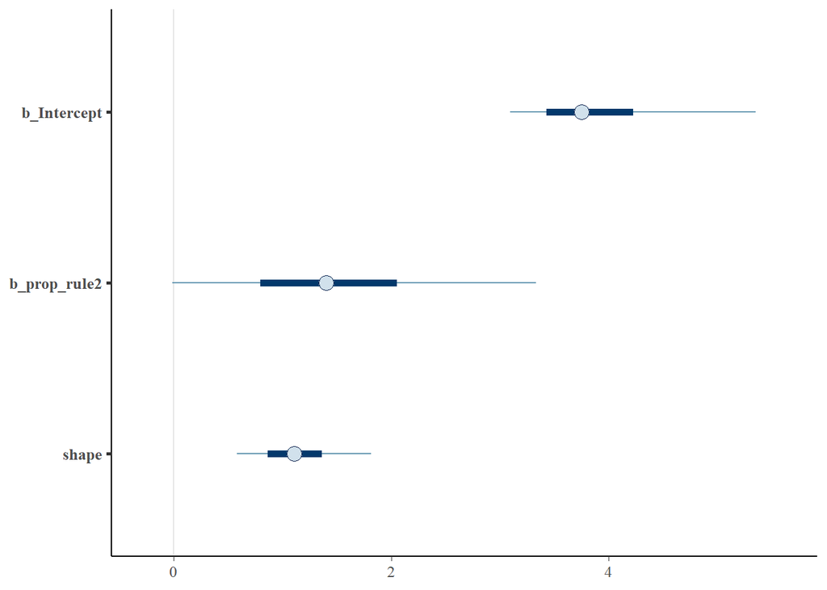

# 10. Herd size when requesting / not requesting

Get data.

| ID | IDinGroup | Group | Condition | round_number | herd_size_after_shock | request |
| --- | --- | --- | --- | --- | --- | --- |
| 2 | 2 | 1 | 1 | 1 | 57 | 1 |
| 4 | 2 | 2 | 1 | 1 | 72 | 0 |
| 6 | 2 | 3 | 1 | 1 | 71 | 1 |
| 8 | 2 | 4 | 1 | 1 | 72 | 0 |
| 10 | 2 | 5 | 1 | 1 | 62 | 1 |
| 12 | 2 | 6 | 1 | 1 | 59 | 0 |
| 14 | 2 | 7 | 1 | 1 | 73 | 1 |
| 16 | 2 | 8 | 1 | 1 | 68 | 1 |
| 18 | 2 | 9 | 1 | 1 | 74 | 0 |
| 20 | 2 | 10 | 1 | 1 | 59 | 0 |

[output cut: 667 more lines]

Fit model.

```
## function(d3.10) {
##   brm(herd_size_after_shock ~ 0 + Intercept + round_number + Condition*request +
##         (1 + round_number | ID),
##       data = d3.10,
##       prior = c(prior(normal(0, 100), class = b, coef = 'Intercept'),
##                 prior(normal(0, 5), class = b, coef = 'round_number'),
##                 prior(normal(0, 5), class = b, coef = 'Condition'),
##                 prior(normal(0, 5), class = b, coef = 'request'),
##                 prior(normal(0, 5), class = b, coef = 'Condition:request')),
##       iter = 4000, warmup = 2000, chains = 4, cores = 4,
##       control = list(adapt_delta = 0.95),
##       sample_prior = TRUE, seed = 2113)
## }
```

Priors.

| prior | class | coef | group | resp | dpar | nlpar | bound |
| --- | --- | --- | --- | --- | --- | --- | --- |
| lkj_corr_cholesky(1) | L |  |  |  |  |  |  |
|  | L |  | ID |  |  |  |  |
|  | b |  |  |  |  |  |  |
| normal(0, 5) | b | Condition |  |  |  |  |  |
| normal(0, 5) | b | Condition:request |  |  |  |  |  |
| normal(0, 100) | b | Intercept |  |  |  |  |  |
| normal(0, 5) | b | request |  |  |  |  |  |
| normal(0, 5) | b | round_number |  |  |  |  |  |
| student_t(3, 0, 12) | sd |  |  |  |  |  |  |
|  | sd |  | ID |  |  |  |  |

[output cut: 3 more lines]

Print results.

```
##  Family: gaussian
##   Links: mu = identity; sigma = identity
## Formula: herd_size_after_shock ~ 0 + Intercept + round_number + Condition * request + (1 + round_number | ID)
##    Data: d3.10 (Number of observations: 677)
## Samples: 4 chains, each with iter = 4000; warmup = 2000; thin = 1;
##          total post-warmup samples = 8000
##
## Group-Level Effects:
## ~ID (Number of levels: 42)
##                             Estimate Est.Error l-95% CI u-95% CI Rhat Bulk_ESS Tail_ESS
## sd(Intercept)                   7.78      1.10     5.89    10.17 1.00     2839     5112
## sd(round_number)                1.62      0.24     1.20     2.16 1.00     1349     2538
## cor(Intercept,round_number)    -0.47      0.14    -0.72    -0.16 1.00     1308     2339
##
## Population-Level Effects:
##                   Estimate Est.Error l-95% CI u-95% CI Rhat Bulk_ESS Tail_ESS
## Intercept            73.72      1.77    70.25    77.19 1.00     2146     3549
## round_number         -0.21      0.29    -0.81     0.33 1.00     1583     2669
## Condition             1.36      2.11    -2.83     5.56 1.00     2282     3657
## request              -5.70      1.05    -7.72    -3.67 1.00     8001     6580
## Condition:request    -2.40      1.44    -5.21     0.40 1.00     7753     6446
##
## Family Specific Parameters:
##       Estimate Est.Error l-95% CI u-95% CI Rhat Bulk_ESS Tail_ESS
## sigma     6.55      0.19     6.20     6.95 1.00    10396     5786
##
## Samples were drawn using sampling(NUTS). For each parameter, Bulk_ESS
## and Tail_ESS are effective sample size measures, and Rhat is the potential
## scale reduction factor on split chains (at convergence, Rhat = 1).
```

For participants in the Visible condition, posterior herd size when not requesting:

```
## [1] 73.75
```

And when requesting:

```
## [1] 68.05
```

For participants in the Hidden condition, posterior herd size when not requesting:

```
## [1] 75.06
```

And when requesting:

```
## [1] 66.98
```

Does the herd size when requesting differ across conditions? Get the posterior difference.

```
##  2.5%   50% 97.5%
## -5.57 -1.05  3.50
```

No.

# 11. Amount requested

Get data. We log the outcome as `request_amount` follows an exponential distribution.

| ID | IDinGroup | Group | Condition | round_number | herd_size_after_shock | request_amount | request_amount.log |
| --- | --- | --- | --- | --- | --- | --- | --- |
| 2 | 2 | 1 | 1 | 1 | 57 | 20 | 2.9957323 |
| 6 | 2 | 3 | 1 | 1 | 71 | 2 | 0.6931472 |
| 10 | 2 | 5 | 1 | 1 | 62 | 2 | 0.6931472 |
| 14 | 2 | 7 | 1 | 1 | 73 | 2 | 0.6931472 |
| 16 | 2 | 8 | 1 | 1 | 68 | 2 | 0.6931472 |
| 22 | 2 | 11 | 1 | 1 | 64 | 20 | 2.9957323 |
| 24 | 2 | 12 | 1 | 1 | 68 | 3 | 1.0986123 |
| 26 | 2 | 13 | 1 | 1 | 63 | 69 | 4.2341065 |
| 32 | 2 | 16 | 1 | 1 | 68 | 2 | 0.6931472 |
| 38 | 2 | 19 | 1 | 1 | 77 | 1 | 0.0000000 |

[output cut: 151 more lines]

Fit model.

```
## function(d3.11) {
##   brm(request_amount.log ~ 0 + Intercept + round_number + Condition +
##         (1 + round_number | ID),
##       data = d3.11,
##       prior = c(prior(normal(0, 5), class = b, coef = 'Intercept'),
##                 prior(normal(0, 2), class = b, coef = 'round_number'),
##                 prior(normal(0, 2), class = b, coef = 'Condition')),
##       iter = 2000, warmup = 1000, chains = 4, cores = 4,
##       control = list(adapt_delta = 0.99),
##       sample_prior = TRUE, seed = 2113)
## }
```

Priors.

| prior | class | coef | group | resp | dpar | nlpar | bound |
| --- | --- | --- | --- | --- | --- | --- | --- |
| lkj_corr_cholesky(1) | L |  |  |  |  |  |  |
|  | L |  | ID |  |  |  |  |
|  | b |  |  |  |  |  |  |
| normal(0, 2) | b | Condition |  |  |  |  |  |
| normal(0, 5) | b | Intercept |  |  |  |  |  |
| normal(0, 2) | b | round_number |  |  |  |  |  |
| student_t(3, 0, 10) | sd |  |  |  |  |  |  |
|  | sd |  | ID |  |  |  |  |
|  | sd | Intercept | ID |  |  |  |  |
|  | sd | round_number | ID |  |  |  |  |

[output cut: 1 more lines]

Print results.

```
##  Family: gaussian
##   Links: mu = identity; sigma = identity
## Formula: request_amount.log ~ 0 + Intercept + round_number + Condition + (1 + round_number | ID)
##    Data: d3.11 (Number of observations: 161)
## Samples: 4 chains, each with iter = 2000; warmup = 1000; thin = 1;
##          total post-warmup samples = 4000
##
## Group-Level Effects:
## ~ID (Number of levels: 39)
##                             Estimate Est.Error l-95% CI u-95% CI Rhat Bulk_ESS Tail_ESS
## sd(Intercept)                   0.63      0.12     0.43     0.89 1.00     1171     2276
## sd(round_number)                0.02      0.02     0.00     0.07 1.00      566      949
## cor(Intercept,round_number)    -0.28      0.50    -0.94     0.84 1.00     2135     2468
##
## Population-Level Effects:
##              Estimate Est.Error l-95% CI u-95% CI Rhat Bulk_ESS Tail_ESS
## Intercept        0.99      0.19     0.62     1.35 1.01     1256     1693
## round_number     0.03      0.01     0.01     0.05 1.00     3304     2856
## Condition        0.14      0.23    -0.33     0.60 1.01     1363     2099
##
## Family Specific Parameters:
##       Estimate Est.Error l-95% CI u-95% CI Rhat Bulk_ESS Tail_ESS
## sigma     0.62      0.04     0.54     0.70 1.00     2468     2676
##
## Samples were drawn using sampling(NUTS). For each parameter, Bulk_ESS
## and Tail_ESS are effective sample size measures, and Rhat is the potential
## scale reduction factor on split chains (at convergence, Rhat = 1).
```

How many cattle are requested on average by participants in the Visible condition?

```
## [1] 2.68
```

And in the Hidden condition?

```
## [1] 3.11
```

Do these amounts differ?

```r
quantile(exp(post$b_Intercept) - exp(post$b_Intercept + post$b_Condition), c(.025, .5, .975)) %>% round(2)
```

```
##  2.5%   50% 97.5%
## -1.79 -0.41  0.99
```

No.

# 12. Difference between amount requested and amount required

Get data. We focus only on requests made when beneath the threshold, and calculate the `diff` between the amount requested and the amount required to get to 64 (the minimum threshold).

| ID | IDinGroup | Group | Condition | round_number | herd_size_after_shock | request_amount | diff |
| --- | --- | --- | --- | --- | --- | --- | --- |
| 2 | 2 | 1 | 1 | 1 | 57 | 20 | 13 |
| 10 | 2 | 5 | 1 | 1 | 62 | 2 | 0 |
| 26 | 2 | 13 | 1 | 1 | 63 | 69 | 68 |
| 48 | 2 | 24 | 0 | 1 | 58 | 4 | -2 |
| 72 | 2 | 36 | 0 | 1 | 62 | 2 | 0 |
| 2 | 2 | 1 | 1 | 2 | 58 | 8 | 2 |
| 12 | 2 | 6 | 1 | 2 | 49 | 2 | -13 |
| 20 | 2 | 10 | 1 | 2 | 61 | 3 | 0 |
| 26 | 2 | 13 | 1 | 2 | 53 | 30 | 19 |
| 42 | 2 | 21 | 1 | 2 | 55 | 6 | -3 |

[output cut: 42 more lines]

Fit model.

```
## function(d3.12) {
##   # deal with outliers by using student-t distribution
##   # https://solomonkurz.netlify.app/post/robust-linear-regression-with-the-robust-student-s-t-distribution/
##   brm(bf(diff ~ 0 + Intercept + round_number + Condition +
##         (1 + round_number | ID), nu = 4),
##       data = d3.12, family = student,
##       prior = c(prior(normal(0, 2), class = b, coef = 'Intercept'),
##                 prior(normal(0, 2), class = b, coef = 'round_number'),
##                 prior(normal(0, 2), class = b, coef = 'Condition')),
##       iter = 2000, warmup = 1000, chains = 4, cores = 4,
##       control = list(adapt_delta = 0.99),
##       sample_prior = TRUE, seed = 2113)
## }
```

Priors.

| prior | class | coef | group | resp | dpar | nlpar | bound |
| --- | --- | --- | --- | --- | --- | --- | --- |
|  | b |  |  |  |  |  |  |
| normal(0, 2) | b | Condition |  |  |  |  |  |
| normal(0, 2) | b | Intercept |  |  |  |  |  |
| normal(0, 2) | b | round_number |  |  |  |  |  |
| lkj_corr_cholesky(1) | L |  |  |  |  |  |  |
|  | L |  | ID |  |  |  |  |
| student_t(3, 0, 10) | sd |  |  |  |  |  |  |
|  | sd |  | ID |  |  |  |  |
|  | sd | Intercept | ID |  |  |  |  |
|  | sd | round_number | ID |  |  |  |  |

[output cut: 1 more lines]

Print results.

```
##  Family: student
##   Links: mu = identity; sigma = identity; nu = identity
## Formula: diff ~ 0 + Intercept + round_number + Condition + (1 + round_number | ID)
##          nu = 4
##    Data: d3.12 (Number of observations: 52)
## Samples: 4 chains, each with iter = 2000; warmup = 1000; thin = 1;
##          total post-warmup samples = 4000
##
## Group-Level Effects:
## ~ID (Number of levels: 22)
##                             Estimate Est.Error l-95% CI u-95% CI Rhat Bulk_ESS Tail_ESS
## sd(Intercept)                   5.81      2.70     0.86    11.47 1.00      520      994
## sd(round_number)                0.49      0.33     0.03     1.25 1.00      585     1402
## cor(Intercept,round_number)    -0.26      0.58    -0.98     0.90 1.00      981     1738
##
## Population-Level Effects:
##              Estimate Est.Error l-95% CI u-95% CI Rhat Bulk_ESS Tail_ESS
## Intercept        0.55      1.52    -2.53     3.51 1.00     3183     2754
## round_number    -0.26      0.22    -0.72     0.17 1.00     2133     2217
## Condition        0.74      1.61    -2.44     3.88 1.00     3473     3053
##
## Family Specific Parameters:
##       Estimate Est.Error l-95% CI u-95% CI Rhat Bulk_ESS Tail_ESS
## sigma     4.46      0.90     2.95     6.44 1.00     1169     2195
##
## Samples were drawn using sampling(NUTS). For each parameter, Bulk_ESS
## and Tail_ESS are effective sample size measures, and Rhat is the potential
## scale reduction factor on split chains (at convergence, Rhat = 1).
```

What’s the posterior `diff` score for participants in the Visible condition? A positive score indicates asking for “too many” resources, while a negative number indicates asking for “too few”.

```
##  2.5%   50% 97.5%
## -2.53  0.58  3.51
```

```
##  2.5%   50% 97.5%
## -2.35  1.29  5.04
```

Neither differ from zero.

# 13. Difference between amount requested by partner and amount given

Get data. `diff` is the difference between amount requested by partner and amount given.

| ID | IDinGroup | Group | Condition | round_number | gave | partner_requested | diff |
| --- | --- | --- | --- | --- | --- | --- | --- |
| 6 | 2 | 3 | 1 | 1 | 0 | 4 | -4 |
| 8 | 2 | 4 | 1 | 1 | 3 | 5 | -2 |
| 12 | 2 | 6 | 1 | 1 | 1 | 3 | -2 |
| 20 | 2 | 10 | 1 | 1 | 0 | 11 | -11 |
| 22 | 2 | 11 | 1 | 1 | 1 | 5 | -4 |
| 30 | 2 | 15 | 1 | 1 | 4 | 5 | -1 |
| 32 | 2 | 16 | 1 | 1 | 0 | 5 | -5 |
| 42 | 2 | 21 | 1 | 1 | 5 | 5 | 0 |
| 46 | 2 | 23 | 0 | 1 | 3 | 2 | 1 |
| 48 | 2 | 24 | 0 | 1 | 1 | 5 | -4 |

[output cut: 184 more lines]

Fit model.

```
## function(d3.13) {
##   # deal with outliers by using student-t distribution
##   # https://solomonkurz.netlify.app/post/robust-linear-regression-with-the-robust-student-s-t-distribution/
##   brm(bf(diff ~ 0 + Intercept + round_number + Condition +
##            (1 + round_number | ID), nu = 4),
##       data = d3.13, family = student,
##       prior = c(prior(normal(0, 5), class = b, coef = 'Intercept'),
##                 prior(normal(0, 2), class = b, coef = 'round_number'),
##                 prior(normal(0, 2), class = b, coef = 'Condition')),
##       iter = 4000, warmup = 2000, chains = 4, cores = 4,
##       control = list(adapt_delta = 0.99),
##       sample_prior = TRUE, seed = 2113)
## }
```

Priors.

| prior | class | coef | group | resp | dpar | nlpar | bound |
| --- | --- | --- | --- | --- | --- | --- | --- |
| lkj_corr_cholesky(1) | L |  |  |  |  |  |  |
|  | L |  | ID |  |  |  |  |
|  | b |  |  |  |  |  |  |
| normal(0, 2) | b | Condition |  |  |  |  |  |
| normal(0, 5) | b | Intercept |  |  |  |  |  |
| normal(0, 2) | b | round_number |  |  |  |  |  |
| student_t(3, 0, 10) | sd |  |  |  |  |  |  |
|  | sd |  | ID |  |  |  |  |
|  | sd | Intercept | ID |  |  |  |  |
|  | sd | round_number | ID |  |  |  |  |

[output cut: 1 more lines]

Print results.

```
##  Family: student
##   Links: mu = identity; sigma = identity; nu = identity
## Formula: diff ~ 0 + Intercept + round_number + Condition + (1 + round_number | ID)
##          nu = 4
##    Data: d3.13 (Number of observations: 194)
## Samples: 4 chains, each with iter = 4000; warmup = 2000; thin = 1;
##          total post-warmup samples = 8000
##
## Group-Level Effects:
## ~ID (Number of levels: 39)
##                             Estimate Est.Error l-95% CI u-95% CI Rhat Bulk_ESS Tail_ESS
## sd(Intercept)                   1.11      0.43     0.18     1.97 1.00     1373      971
## sd(round_number)                0.06      0.05     0.00     0.19 1.00     1143     1168
## cor(Intercept,round_number)     0.08      0.56    -0.92     0.96 1.00     4048     4454
##
## Population-Level Effects:
##              Estimate Est.Error l-95% CI u-95% CI Rhat Bulk_ESS Tail_ESS
## Intercept       -0.28      0.47    -1.19     0.66 1.00     4483     5034
## round_number    -0.05      0.04    -0.13     0.02 1.00     2750     2071
## Condition       -1.44      0.56    -2.53    -0.32 1.00     4815     4711
##
## Family Specific Parameters:
##       Estimate Est.Error l-95% CI u-95% CI Rhat Bulk_ESS Tail_ESS
## sigma     1.99      0.18     1.67     2.36 1.00     5758     5506
##
## Samples were drawn using sampling(NUTS). For each parameter, Bulk_ESS
## and Tail_ESS are effective sample size measures, and Rhat is the potential
## scale reduction factor on split chains (at convergence, Rhat = 1).
```

What’s the posterior `diff` score for participants in the Visible condition?

```
##  2.5%   50% 97.5%
## -1.19 -0.28  0.66
```

What about participants in the Hidden condition?

```
##  2.5%   50% 97.5%
## -2.59 -1.72 -0.83
```

Participants in the Hidden condition give 2 cattle less than was requested, on average.